# Point Pattern Analysis

# Data wrangling

We begin by bringing the datasets into the required (ppp) format from the sf format they’re currently in. First, we read in the datasets.

```r
# Reading in cleaned offense data and keeping only necessary variables
arrests_sf <- st_read("./datasets/arrests.cleaned_sf/arrests.cleaned_sf.shp")
briefarrests_sf <- subset(arrests_sf,
                          select = "geometry")

# Reading in cleaned liquor data and keeping only necessary variables
liquor_sf <- st_read("./datasets/liquor.cleaned_sf/liquor.cleaned_sf.shp")
briefliquor_sf <- subset(liquor_sf, select ="geometry")
```

Next we append the datasets. By only keeping necessary variables, we’ve ensured that column names in both arrests and liquor datasets have the same column names. It is important to append so that we can conduct analysis for both kinds of datapoints within the same geographic area and explore relations accordingly.

```r
# We create a column in both datasets to identify whether a point represents a liquor license location or an offense location after appending
briefarrests_sf$from_liquor <- "offense"
briefliquor_sf$from_liquor <- "liquor"

# Appending
main_pattern <- rbind(briefliquor_sf,briefarrests_sf)

# Converting from_liquor to factor; this variable will be used as a 'mark' - an attribute associated with a point/event - which must be in a factor format
main_pattern$from_liquor <- as.factor(main_pattern$from_liquor)
```

Next we read in the boundaries for DC. This will be used as a ‘window’ which identifies the area within which the analysis is to be conducted.

```r
# Reading in DC's boundaries
dc <- readShapeSpatial("./datasets/Washington_DC_Boundary-shp/3e1cb723-752b-4300-a022-f1a1f3667e47202043-1-1re4u28.ia88k.shp")
```

Now that we have the required files - an appended file with liquor license and offense locations (points/events) and DC’s boundaries (the window) we’re ready to convert to spatstat’s default file format - ppp.

```r
# Setting DC boundaries to be the 'window'
dc_sp <- as(dc, "SpatialPolygons")
dc_window <- maptools::as.owin.SpatialPolygons(dc_sp)

# Setting liquor license and offense locations to be events
sf_mainpat_coords <- matrix(unlist(main_pattern$geometry), ncol = 2, byrow = T)

# Bringing it together, to create ppp dataset
mainpat_ppp <- ppp(x = sf_mainpat_coords[,1],
                   y = sf_mainpat_coords[,2],
                   window = dc_window, check = T,
                   marks = main_pattern$from_liquor)
```

```
## Warning: data contain duplicated points
```

```r
# Inspecting for duplicates
sum(multiplicity(mainpat_ppp) > 1)
```

```
## [1] 245
```

But this throws the warning that the file contains duplicate location values. There are 245 locations with more than one incidence of crimes - possibly when there are repeat offences or multiple offences in the same instance. Spatstat package assumes each event to be unique, thus this issue must be addressed. However, it would be incorrect to delete these instances as it would reduce the intensity of crime. Instead, we resort to jittering - moving points the minimal amount to prevent a perfect overlap.

```r
jitter_mainpat <- rjitter(mainpat_ppp, retry=TRUE, nsim=1, drop=TRUE)

# Checking again - no duplicates!
sum(multiplicity(jitter_mainpat) > 1)
```

```
## [1] 0
```

We also create separate ppp files for offenses and liquor which will be useful for visualization purposes.

```r
# For liquor
sf_liquor_coords <-
  matrix(unlist(briefliquor_sf$geometry),
                           ncol = 2, byrow = T)

liquor_ppp <- ppp(x = sf_liquor_coords[,1],
                   y = sf_liquor_coords[,2],
                   window = dc_window, check = T)

jitter_liquor <- rjitter(liquor_ppp, retry=TRUE, nsim=1, drop=TRUE)

# For arrests
sf_arrests_coords <-
  matrix(unlist(briefarrests_sf$geometry),
                           ncol = 2, byrow = T)

arrests_ppp <- ppp(x = sf_arrests_coords[,1],
                   y = sf_arrests_coords[,2],
                   window = dc_window, check = T)

jitter_arrests <- rjitter(arrests_ppp, retry=TRUE, nsim=1, drop=TRUE)
```

Our files are ready! Now onto the analysis.

## Kernel density estimation

Density shows the number of points per unit area. The bandwith determines the division of areas within which points are counted. The wider the bandwidth, the more minute detail is lost. The bandwith method selected here is bw.ppl which is recommended for cases where data is likely in multiple clusters (which is the assumption based on data observed in the previous section).

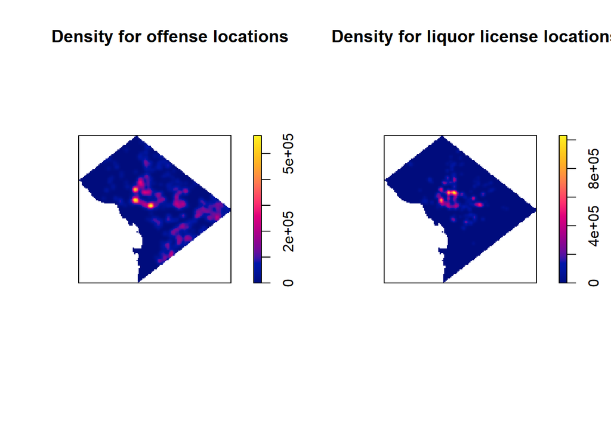

```r
darrest <- density.ppp(jitter_arrests, sigma = bw.ppl(jitter_arrests))

dliquor <- density.ppp(jitter_liquor,sigma =bw.ppl(jitter_liquor))

par(mfrow=c(1,2))
plot(darrest, main="Density for offense locations" )
plot(dliquor, main="Density for liquor license locations")
```

This plot indicates that arrests data has more clusters than liquor data. Specifically, the cluster in central DC visually seems to overlap - indicating a potential relationship.

This can be explored further and more formally through Ripley’s K method.

## Cross K Function (Ripley’s)

The cross-K function used here, is based on the average number of offenses within a certain distance of a liquor license location. It compares the observed data to a distribution that would be expected if the points were randomly distributed (rather than clustered in relation to each other). It essentially answers the question - could this clustering have occured simply by random chance? We use the inhomogenous version of K-cross as it is evident from the density plot that the distribution of points is not homogenous/uniform.

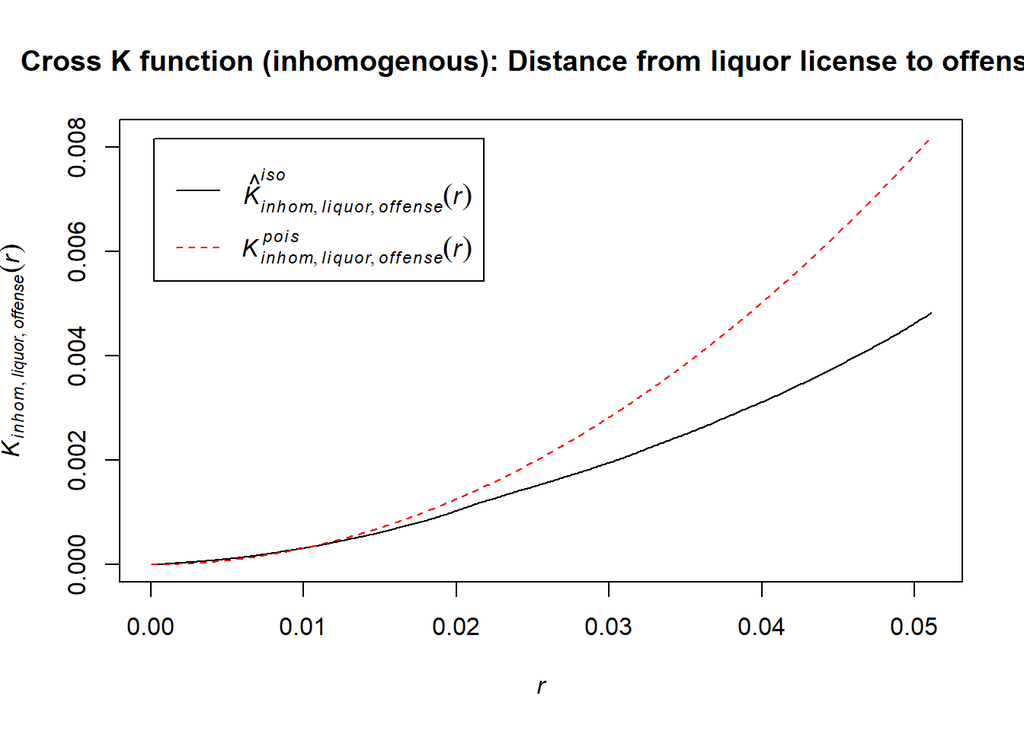

```r
Karrests <- Kcross.inhom(jitter_mainpat,
                   i = "liquor",
                   j = "offense",
                   correction = "Ripley",
                   lambdai =dliquor,
                   labdaj = darrest)

plot(Karrests, main = "Cross K function (inhomogenous): Distance from liquor license to offenses")
```

Here we see that the black line for distribution of observed points lies below the red line theorised for a random distribution of points. This, interestingly, implies that liquor licenses repel, rather than attract offenses.

Let’s explore the significance of this finding with the envelope funtion.

## Envelope

The envelope function uses a Monte Carlo simulation randomly assigning points as offense or liquor license points. It runs such a simulation 99 times and if the curve representing the observed points falls within the confidence interval of the simulation, it implies that the pattern of clustering doesn’t change even when the the categories are randomly assigned. The null hypothesis is that the two distributions are spatially independent. If the observed data falls within the ‘envelope’ or confidence interval of this null hypothesis, then we fail to reject it. That shows no significant relation between the location of liquor stores and offenses.

```r
envarrests <- envelope(jitter_mainpat, fun=Kcross,
                  nsim=99,
                  i="liquor",j="offense",
                  simulate=expression
                  (rlabel(jitter_mainpat)),
                  correction = "Ripley")
```

[output not shown]

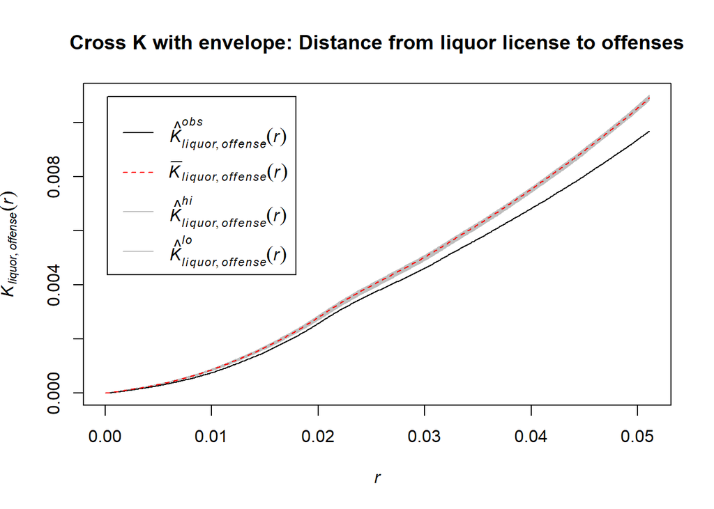

```r
plot(envarrests, main = "Cross K with envelope: Distance from liquor license to offenses")
```

More can be understood through regressions with added controls.